# Bayesian Inferece for IID Gamma Distributed Data

### What is this example about?

There are two least two different ways to define the probability density function (pdf) of a Gamma distribution. To avoid any confusion, in this tutorial when we write $X \sim \mbox{Gamma}(\alpha,\beta)$ the pdf is given as follows:
$$f_X(x|\alpha, \beta) = \frac{\beta^\alpha}{\Gamma(\alpha)} x^{\alpha - 1} \exp\{-\beta x\}, \quad x>0, \, \alpha>0,\, \beta>0.$$

### Setting up the scene

Suppose that we are given some i.i.d data, ${\bf y}=(y_1, \ldots, y_n)$, and assume that
$$y_i \sim \mbox{Gamma}(\alpha,\beta), \quad i = 1,\ldots, n.$$
We wish to estimate the parameters of the Gamma distribution $\alpha, \beta)$ within a Bayesian framework.

### Priors

Since we are operating within a Bayesian framework we need to assign prior distributions to the parameters of interest $\alpha$ and $\beta$. Both parameters are positive so a natural to distribution to represent our prior beliefs them is a Gamma distribution. We will also assume that *a priori* (ie before we see the data) that the parameters are independent. Hence:
$$\alpha \sim \mbox{Gamma}(\lambda_{\alpha}, \nu_{\alpha})$$
$$\beta \sim \mbox{Gamma}(\lambda_{\beta}, \nu_{\beta})$$

The corresponding pdfs of these Gamma distributions are:
$$\pi(\alpha) = \frac{\nu_{\alpha}^{\lambda{\alpha}}}{\Gamma(\lambda_\alpha)} \alpha^{\lambda_{\alpha}-1} \exp\{-\alpha \nu_\alpha\} \propto \alpha^{\lambda_\alpha-1} \exp\{-\alpha \nu_\alpha \}$$

$$\pi(\beta) = \frac{\nu_{\beta}^{\lambda{\beta}}}{\Gamma(\lambda_\beta)} \alpha^{\lambda_{\beta}-1} \exp\{-\beta \nu_\beta\} \propto \beta^{\lambda_\beta-1} \exp\{-\beta \nu_\beta \}$$

### Likelihood function

The likelihood function, denoted by $L(\alpha, \beta)$ is a product of the densities $f(y_i|\alpha, \beta)$ since we have i.i.d. data:
$$L(\alpha,\beta) = \pi({\bf y}|\alpha, \beta) = \prod_{i=1}^{n}f(y_i|\alpha, \beta) = \prod_{i=1}^{n}\frac{\beta^\alpha}{\Gamma(\alpha)} y_i^{\alpha - 1} \exp\{-\beta y_i\}$$
It is easy to see that the likelihood function is equal to:
$$\pi({\bf y}|\alpha, \beta) = \frac{\beta^{n\alpha}}{\Gamma(\alpha)^n} \prod_{i=1}^{n} y_i^{\alpha-1} \exp\left\{-\beta\sum_{i=1}^{n}y_i\right\}$$

### Posterior Distribution

The density of the posterior distribution is up to proportionality the product of the likelihood functions times the prior densities:
$$\pi(\alpha, \beta|{\bf y}) \propto \pi({\bf y}|\alpha, \beta) \pi(\alpha) \pi(\beta)$$
Using the expression above we derive (up to proportionality) the density of the joint posterior distribution of the parameters given the data:
$$\pi(\alpha, \beta|{\bf y}) \propto \frac{\beta^{n\alpha}}{\Gamma(\alpha)^n} \prod_{i=1}^{n} y_i^{\alpha-1} \exp\left\{-\beta\sum_{i=1}^{n}y_i\right\} \times \alpha^{\lambda_\alpha-1} \exp\{-\alpha \nu_\alpha \} \times \beta^{\lambda_\beta-1} \exp\{-\beta \nu_\beta \}$$

## Markov Chain Monte Carlo

We would like to draw samples from this distribution using MCMC. The first thing we need to do, is to write down the full conditional distribution of the parameters:

### Full Conditionals

To derive the full conditional density of the distribution of one of the parameters, say, $\alpha$, we just look at the joint posterior density and put together the terms that only involve $\alpha$. Everything else is treated as a constant:
$$\pi(\alpha|\beta, {\bf y}) \propto \frac{\beta^{n\alpha}}{\Gamma(\alpha)^n} \left(\prod_{i=1}^{n} y_i^{\alpha-1}\right) \alpha^{\lambda_\alpha-1} \exp\{-\alpha \nu_\alpha \}$$
Similarly, the density of full conditional posterior distribution of $\beta$ given everything else is given as:
$$\pi(\beta|\alpha, {\bf y}) \propto \beta^{n\alpha} \exp\left\{-\beta\sum_{i=1}^{n}y_i\right\} \beta^{\lambda_\beta-1} \exp\{-\beta \nu_\beta \} = \beta^{n\alpha + \lambda_\beta -1} \exp\left\{-\beta\left(\sum_{i=1}^{n}y_i + \nu_{\beta} \right) \right \}$$

Therefore for $\beta$ we can sample directly from its conditional distribution.

A pseudo-code for implementing a Metropolis Hastings algorithm:

1. Initialisation;
2. Sample from $(\pi(\alpha|\beta, {\bf y}))$
3. Sample from $(\pi(\beta|\alpha, {\bf y}))$
4. Goto 2

## R-code

We will now write some `R` functions which will enable us to implement the above algorithm in the computer.

We first write functions to compute the (log) gamma density with parameters $\lambda$ and $\nu$ for a random variable $\theta$ up to proportionality:

```r
log.gamma.density <- function(theta, lambda, nu) {

   out <- (lambda-1)*log(theta) - theta*nu
   return(out)
}
```

We now write a function that takes as arguments the data (vector), the number of MCMC iterations (scalar), the tuning varianaces for the random walk Metropolis (vector), and the values of the parameters for the prior distributios (scalars):

```r
mcmc <- function(y, iter, sigma.rw, lambda.alpha, lambda.beta, nu.alpha, nu.beta) {

   # find n from the data (ie the number of observations)
   n <- length(y)

   # compute the sum of the observations and the sum of the log of the observations
   sum.y <- sum(y)
   sum.log.y <- sum(log(y))

   # first create a table which will store the samples; first column will be alpha, second will be beta
   out <- matrix(NA, nrow=iter, ncol=2)

   # initial values
   alpha.cur <- 1
   beta.cur <- 1
   out[1,] <- c(alpha.cur, beta.cur)

   # mcmc loop starts here
   for (i in 2:iter) {

      ###############
      # update alpha (assume beta is fixed)
      ###############

      # propose a new value for alpha
      alpha.can <- rnorm(1, alpha.cur, sigma.rw)

      # if it is negative reject straight away else compute the M-H ratio
      if (alpha.can > 0) {

           # evaluate the loglikelihood at the current values of alpha.
          loglik.cur <- n*alpha.cur*log(beta.cur) - n*lgamma(alpha.cur) + (alpha.cur-1)*sum.log.y

         # compute the log-likelihood at the candidate value of alpha
         loglik.can <- n*alpha.can*log(beta.cur) - n*lgamma(alpha.can) + (alpha.can-1)*sum.log.y


         # log prior densities
         log.prior.alpha.cur <- log.gamma.density(alpha.cur, lambda.alpha, nu.alpha)
         log.prior.alpha.can <- log.gamma.density(alpha.can, lambda.alpha, nu.alpha)

         logpi.cur <- loglik.cur + log.prior.alpha.cur
         logpi.can <- loglik.can + log.prior.alpha.can

         # M-H ratio

         # draw from a U(0,1)
         u <- runif(1)

         if (log(u) < logpi.can - logpi.cur) {
            alpha.cur <- alpha.can
         }
      }

      ###############
      # update beta
      ###############

      beta.cur <- rgamma(1, alpha.cur*n + lambda.beta, rate = sum.y + nu.beta)

      # store the samples
      out[i,] <- c(alpha.cur, beta.cur)

   }

   return(out)
}
```

### Application

Suppose now that we have some data and we want to fit this model, i.e. that these data a random sample from a Gamma distribution whose parameters we wanto to estimate.

First let us generate some idea to test our code:

```r
data <- rgamma(500, 4, 2)
```

Use the `mcmc` function to draw samples from the posterior distribution of the parameters assuming that $\lambda_{\alpha} = \lambda_\beta = 1$ and $\nu_{\alpha} = \nu_{\beta} = 0.0001$:

```r
res <- res <- mcmc(y = data, iter = 10000, sigma.rw = 1, lambda.alpha = 1, lambda.beta = 1, nu.alpha = 1e-4, nu.beta = 1e-4)
```

Let’s look at the output. First, trace plots to ensure that the chains mix well:

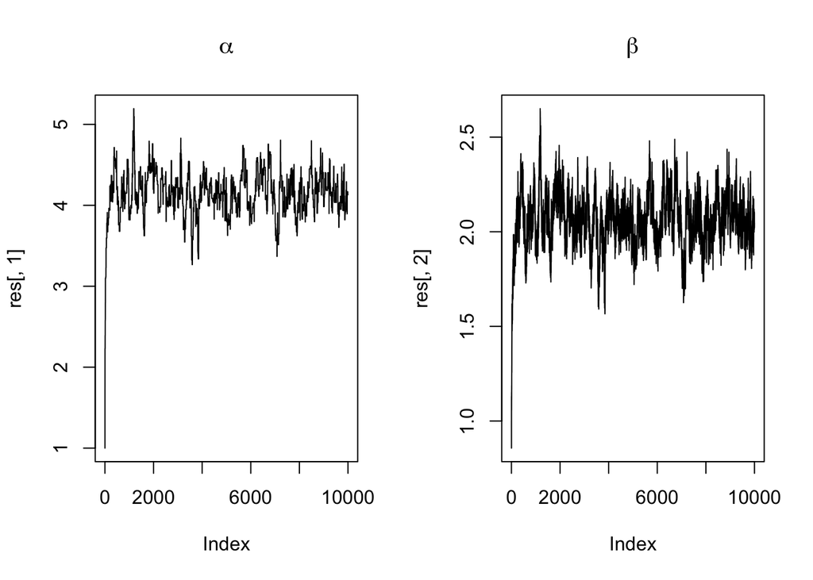

```r
par(mfrow=c(1,2))
plot(res[,1],type='l', main=expression(paste(alpha)))
plot(res[,2],type='l', main=expression(paste(beta)))
```

Exlude the first 1,000 observations as burn in:

```r
res <- res[-c(1:1000),]
```

Next, let us draw some histograms:

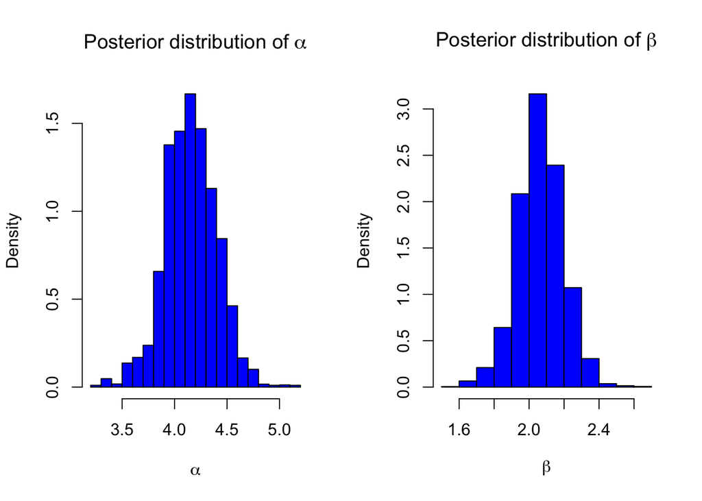

```r
par(mfrow=c(1,2))
hist(res[,1], prob=TRUE, col=4, xlab=expression(paste(alpha)), main=expression(paste("Posterior distribution of ", alpha)))
hist(res[,2], prob=TRUE, col =4, xlab=expression(paste(beta)), main=expression(paste("Posterior distribution of ", beta)))
```

An advantage of a Bayesian approach that we can explore the the joint distribution of the parameters

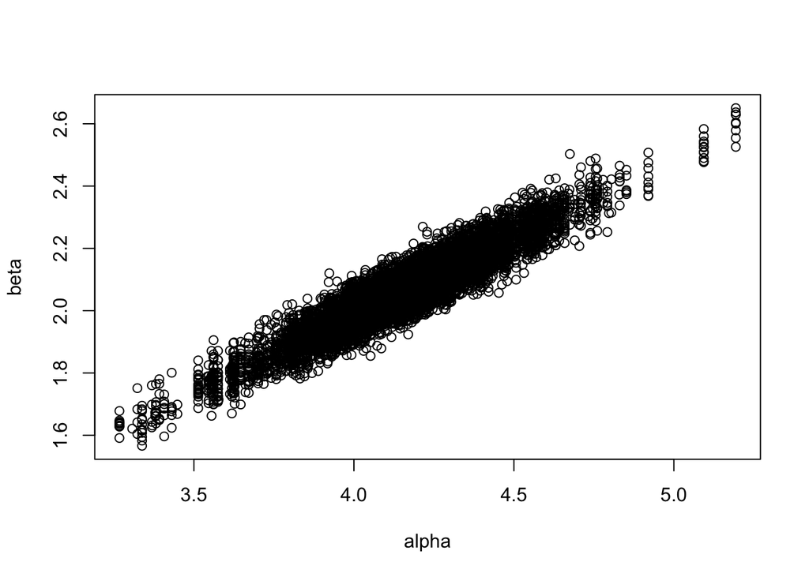

```r
par(mfrow=c(1,1))
plot(res, xlab=paste(expression(alpha)), ylab=paste(expression(beta)))
```